# Place-Level Voter Turnout

Ridhi Purohit, Vincent Pancini and Aaron R. Williams

February 25, 2025 11:45

# Housekeeping

This code book was created by Ridhi Purohit in January 2025 based on the code in file “05_local-governance/voter-turnout/voter-turnout-city-2020.Rmd” to back fill the place-level election turnout metric for the year 2016.

```r
options(scipen = 999)

library(tidyverse)
library(tidyselect)
library(urbnthemes)
library(sf)
library(tigris)
library(areal)

set_urbn_defaults(style = "print")

source(here::here("functions", "testing", "evaluate_final_data.R"))
```

# 1. Numerator

## 1. 2016 Precinct-Level Election Results/Shapefile and Census Place Shapefile

This file uses 2016 Precinct-Level Election Results from the the Voting and Election Science Team (VEST) at University of Florida and Wichita State University, accessed via the Harvard Dataverse ([data here](https://dataverse.harvard.edu/dataset.xhtml?persistentId=doi:10.7910/DVN/NH5S2I)), for state-by-state shapefiles of 2016 precinct-level general election results.

### Read Data

First, the precinct-level shapefiles with election result data is downloaded. Since the Harvard Dataverse website didn’t specify download URLs for this data collection, the page source of each document’s webpage was investigated (by monitoring the API call for download) to find the file IDs for each statewide results file. These IDs are recorded in the ‘id’ column of the ‘states’ data frame.

For more information on how VEST collected election result data and precinct shapefiles, please see their documentation [here](https://dataverse.harvard.edu/file.xhtml?fileId=10596694&version=94.0).

```r
# Create df for all states
states <- tribble(
  ~state, ~statefip, ~id,
  "al", "01", 4751068,
  "ak", "02", 6550193,
  "az", "04", 4773516,
  "ar", "05", 4931773,
  "ca", "06", 3184156,
  "co", "08", 4061282,
  "ct", "09", 4986639,
  "de", "10", 3866541,
  "dc", "11", 3866544,
  "fl", "12", 9865414,
  "ga", "13", 4863152,
  "hi", "15", 3442919,
  "id", "16", 3904486,
  "il", "17", 4749661,
  "in", "18", 5117322,
  "ia", "19", 3612932,
  "ks", "20", 6696060,
  "la", "22", 3644961,
  "me", "23", 5739870,
  "md", "24", 5739867,
  "ma", "25", 5007729,
  "mi", "26", 9865416,
  "mn", "27", 3194092,
  "ms", "28", 5706481,
  "mo", "29", 5007730,
  "mt", "30", 4773518,
  "ne", "31", 4931772,
  "nv", "32", 8569128,
  "nh", "33", 3677990,
  "nm", "35", 5425592,
  "ny", "36", 5706918,
  "nc", "37", 4863151,
  "nd", "38", 4931776,
  "oh", "39", 6174174,
  "ok", "40", 3613878,
  "or", "41", 5194698,
  "pa", "42", 10596695,
  "ri", "44", 4789391,
  "sc", "45", 5739869,
  "sd", "46", 6082784,
  "tn", "47", 5746906,
  "tx", "48", 4934233,
  "ut", "49", 3675144,
  "vt", "50", 4863154,
  "va", "51", 6550194,
  "wa", "53", 8569131,
  "wv", "54", 6418337,
  "wi", "55", 8940330,
  "wy", "56", 4789392,
  "ky", "21", 6429540,
  "nj", "34", 6492869
) %>%
  mutate(url = here::here("05_local-governance", "voter-turnout", "vest",
                          paste0(state, "_2016.zip")))
```

Download precinct-level election turnout and shapefile data

```r
# Create object for VEST directory, and create the directory if it doesn't exist. "vest" is the acronym for the Voting and Election Science Team at University of Florida and Wichita State
vest_directory <- here::here("05_local-governance", "voter-turnout", "vest")

if (!dir.exists(vest_directory)) {

  dir.create(vest_directory)

}

# create a vector of URLs for the state data
urls <- c(
  # Create vector of URLs for all states
  paste0("https://dataverse.harvard.edu/api/access/datafile/",
         states$id[1:51],
         "?gbrecs=true")
)

# Create object for VEST data, and download the zip file for each state if it isn't downloaded

vest_data <- c(
  # All states
  here::here(paste0("05_local-governance/voter-turnout/vest/",
                    states$state[1:51],
                    "_2016.zip"))
)

if (!all(file.exists(vest_data))) {
  # updated code to loop over each url individually and changed mode to 'wb' to download valid files
  for (i in 1:51) {
  download.file(urls[i],
                destfile = vest_data[i], mode = "wb")
  }
}

rm(urls, vest_directory, vest_data)
```

Read in the precinct shapefiles and voting results data for each state. Each data set has several variables that begin with `G16PRE` that indicate the number of votes each presidential candidate received in that precinct. We sum these variables to create a new variable called `total_votes`, and only keep this variable and the geometry. We append all states together and create a `GEOID` variable based on row number which we will need for interpolation later.

```r
read_precinct <- function(file) {

  tempfile <- tempfile()
  unzip(file, exdir = tempfile)

  st_read(tempfile) %>%
    dplyr::mutate(total_votes = across(starts_with("G16PRE")) %>% rowSums) %>%
    # updated code: added "NAME", "COUNTYFP", "STATEFP" to reflect columns in 2016 data
    dplyr::select(any_of(c("STATEFP20", "COUNTYFP20", "NAME16", "COUNTY",
                           "NAME", "COUNTYFP", "STATEFP")), total_votes, geometry) %>%
    sf::st_transform(crs = 5070)

}

# download and read all the precinct data files
precincts <- map(states$url, read_precinct)

# bind all precinct data
precincts <- precincts |>
  reduce(bind_rows)

# create unique GEOID for interpolation
precincts <- precincts |>
  dplyr::mutate(GEOID16 = row_number())
```

The total number of votes reported in this data is 136,519,876. This is 149,361 votes less than [the national vote total in 2016 of 136,669,237](https://en.wikipedia.org/wiki/2016_United_States_presidential_election#Results_by_state).

This discrepancy is likely due to data privacy protection measures referenced in the technical article, [United States Precinct Boundaries and Statewide Partisan Election Results](https://www.nature.com/articles/s41597-024-04024-2) by VEST, quoted below.

> “Sometimes discrepancies are by design. States may censor small vote tallies to protect voters’ confidentiality and the secret ballot. The North Carolina State Board of Elections adds a small amount of noise to their state’s precinct results per state law whenever a candidate receives one hundred percent of the vote within a reporting unit and voters’ choices would be revealed.”

```r
# total number of votes is 136,519,876
precincts |>
  as.data.frame() |>
  summarize(n = sum(total_votes))
```

```
##           n
## 1 136519876
```

Load the census place shapefiles from `library(tigris)` and filter down to 485 cities (for 2016).

Note: South Fulton City, GA is not a city in 2016 but is present for 2020.

```r
read_places <- function(fips) {

  tigris::places(state = fips,
                 cb = TRUE,
                 year = 2016,
                 progress_bar = FALSE) %>%
    select(GEOID, geometry) %>%
    sf::st_transform(crs = 5070)

}

places <- map_df(states$statefip, read_places)

# Read in our 485 places for 2016 and join shapefiles
my_places <- read_csv(here::here("geographic-crosswalks", "data", "place-populations.csv")) %>%
  filter(year == 2016) %>%
  mutate(GEOID = str_c(state, place)) %>%
  left_join(y = places, by = "GEOID") %>%
  st_as_sf()
```

The precinct shapefiles do not all form a closed linestring (i.e., the polygons in these shapefiles do not all have identical start and endpoints). Therefore the geometries are not valid and `aw_interpolate()` does not work.

Furthermore, several of the precinct geometries include Z and/or M dimensions. Z-values are most commonly used to represent elevations, but they can also represent other measurements such as annual rainfall or air quality. M-values are used to interpolate distances along linear features, such as roads, streams, and pipelines (two commonly used M-values are milepost distance from a set location, such as county line, and distance from a reference marker). See [here](https://pro.arcgis.com/en/pro-app/latest/help/data/geodatabases/overview/feature-class-basics.htm) for more information about Z and M values.

```r
# # If we try using `aw_interpolate()`, we get the following: "Error in scan(text = lst[[length(lst)]], quiet = TRUE) : scan() expected 'a real', got 'IllegalArgumentException:' Error in (function (msg)  :  IllegalArgumentException: Points of LinearRing do not form a closed linestring"

#interpolated <- aw_interpolate(.data = places,
#                                tid = GEOID,
#                                source = precincts,
#                                sid = GEOID16,
#                                weight = "total",
#                                output = "sf",
#                                extensive = "total_votes")

# Try to check which observations are invalid
# test <- st_is_valid(precincts)
```

We drop Z/M values from precinct geometries and assign flag for observations with Z/M values. There are 34,946 observations this applies to.

```r
# Create a dummy data set with corrected geometries
test <- precincts %>%
  st_zm(drop = TRUE)

# Anti-join the corrected geometries to the original precinct data to identify which observations had Z/M values. Create a variable to flag these observations. There are 34,946 observations this applies to.
anti_joined <- anti_join(as.data.frame(precincts), as.data.frame(test), by = "geometry") %>%
  mutate(zm_flag = 1) %>%
  select(-geometry)

anti_joined %>%
  nrow()
```

```
## [1] 34946
```

```r
# Now correct geometries in original precinct data
precincts <- precincts %>%
  st_zm(drop = TRUE)

# Join the flags for Z/M values onto our original precinct data and check number of ZM flags
precincts <- left_join(
  precincts,
  select(anti_joined, GEOID16, zm_flag),
  by = "GEOID16"
)

precincts %>%
  as.data.frame() %>%
  dplyr::count(zm_flag)
```

```
##   zm_flag      n
## 1       1  34946
## 2      NA 142255
```

```r
# Replace `NA` values for observations that didn't receive a Z/M flag with `0`, then check number of ZM flags
precincts <- precincts %>%
  mutate(zm_flag = case_when(is.na(zm_flag) ~ 0,
                                  zm_flag == 1 ~ 1))

precincts %>%
  as.data.frame() %>%
  dplyr::count(zm_flag)
```

```
##   zm_flag      n
## 1       0 142255
## 2       1  34946
```

```r
# Remove obsolete data sets
rm(test, anti_joined)
```

We still cannot interpolate yet because there are still 380 invalid geometries for the following reasons: “Hole lies outside shell”, “Nested shells,” “Ring Self-intersection,” “Self-intersection,” and “Too few points in geometry component.” We identify and flag the observations with invalid geometries, and then validate them to perform the interpolation.

```r
# # If we try using `aw_interpolate()`, we get the following: "Error in scan(text = lst[[length(lst)]], quiet = TRUE) : scan() expected 'a real', got '1438886.463491861.' Error in (function (msg)  : TopologyException: side location conflict at 163178.92723236606 1438886.463491861. This can occur if the input geometry is invalid."

# interpolated <- aw_interpolate(.data = places,
#                                tid = GEOID,
#                                source = precincts,
#                                sid = GEOID16,
#                                weight = "total",
#                               output = "sf",
#                                extensive = "total_votes")

# Isolate invalid geometries
invalid_geom <- precincts %>%
  filter(!st_is_valid(precincts))

# Check reasons for invalid geometries
st_is_valid(invalid_geom, reason = TRUE) %>%
  as.data.frame() %>%
  mutate(reason = str_extract(string = st_is_valid(invalid_geom, reason = TRUE),
                              pattern = ".*\\[")) %>%
  dplyr::count(reason)
```

```
##                                  reason   n
## 1              Hole lies outside shell[   2
## 2                        Nested shells[   1
## 3               Ring Self-intersection[ 240
## 4                    Self-intersection[ 128
## 5 Too few points in geometry component[   9
```

```r
# Create a variable to flag these observations
invalid_geom <- invalid_geom %>%
  mutate(invalid_flag = 1) %>%
  as.data.frame() %>%
  select(-geometry, -zm_flag)

# Join the flags for invalid geometries onto our original precinct data and check number of invalid geometries
precincts <- left_join(
  precincts,
  select(invalid_geom, GEOID16, invalid_flag),
  by = "GEOID16",
)

as.data.frame(precincts) %>%
  dplyr::count(invalid_flag)
```

```
##   invalid_flag      n
## 1            1    380
## 2           NA 176821
```

```r
# Replace `NA` values for observations that didn't receive an invalid flag with `0`, then check number of invalid flags
precincts <- precincts %>%
  mutate(invalid_flag = case_when(is.na(invalid_flag) ~ 0,
                                  invalid_flag == 1 ~ 1))

as.data.frame(precincts) %>%
  dplyr::count(invalid_flag)
```

```
##   invalid_flag      n
## 1            0 176821
## 2            1    380
```

```r
# Now that we've flagged which geometries are invalid, we can make them valid to proceed with the interpolation
precincts <- st_make_valid(precincts)

# Remove obsolete data sets
rm(invalid_geom)
```

The number of intersections (60,010) is greater than the number of observations used for the interpolation.

```r
# check overlap
intersections <- st_intersects(precincts, my_places)

sum(lengths(intersections) > 0)
```

```
## [1] 60010
```

### Place Coverage

The following calculates the proportion of area for each place that is covered by the precincts.

```r
# source: places
# target: precincts
places_weights <- aw_preview_weights(
  .data = precincts,
  tid = GEOID16,
  source = my_places,
  sid = GEOID,
  type = "extensive"
)

arrange(places_weights, extensiveTotal)
```

```
## # A tibble: 485 × 3
##    GEOID   extensiveSum extensiveTotal
##    <chr>          <dbl>          <dbl>
##  1 0603526            1          0.721
##  2 0616000            1          0.736
##  3 0678120            1          0.748
##  4 0613014            1          0.762
##  5 0680238            1          0.779
##  6 0624638            1          0.781
##  7 0633000            1          0.794
##  8 0666000            1          0.800
##  9 0659444            1          0.801
## 10 0653896            1          0.803
## # ℹ 475 more rows
```

Some of the places have less than 100% coverage because the shapes include water and the precinct shapes do not include water. Here are maps of some places with less than 90% coverage.

```r
# places with less than 90% coverage
less_90_cover <- places_weights[places_weights$extensiveTotal < 0.90,"GEOID"]

print(as.data.frame(less_90_cover))
```

```
##      GEOID
## 1  0602252
## 2  0603526
## 3  0611194
## 4  0613014
## 5  0613392
## 6  0616000
## 7  0616350
## 8  0622804
## 9  0623182
## 10 0624638
## 11 0626000
## 12 0633000
## 13 0636448
## 14 0637692
```

[output cut: 22 more lines]

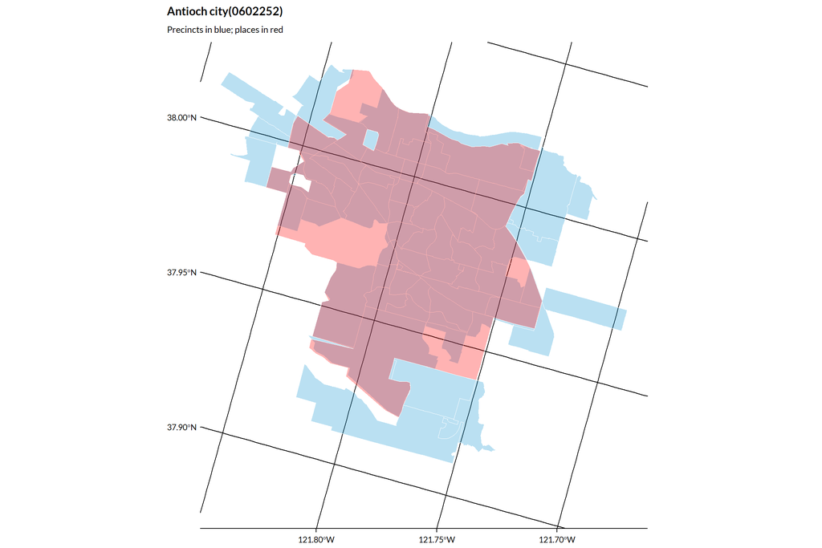

```r
map_trouble <- function(place_id) {

  intersections <- st_intersects(
    precincts,
    filter(my_places, GEOID == place_id)
  )

  precincts <- precincts[lengths(intersections) > 0, ]

  place <- filter(my_places, GEOID == place_id)

  ggplot() +
    geom_sf(data = precincts,
            alpha = 0.3) +
    geom_sf(data = place,
            alpha = 0.3, fill = "red") +
    labs(
      title = paste0(place$place_name, "(", place_id, ")"),
      subtitle = "Precincts in blue; places in red"
    )

}

map_trouble("0602252")
```

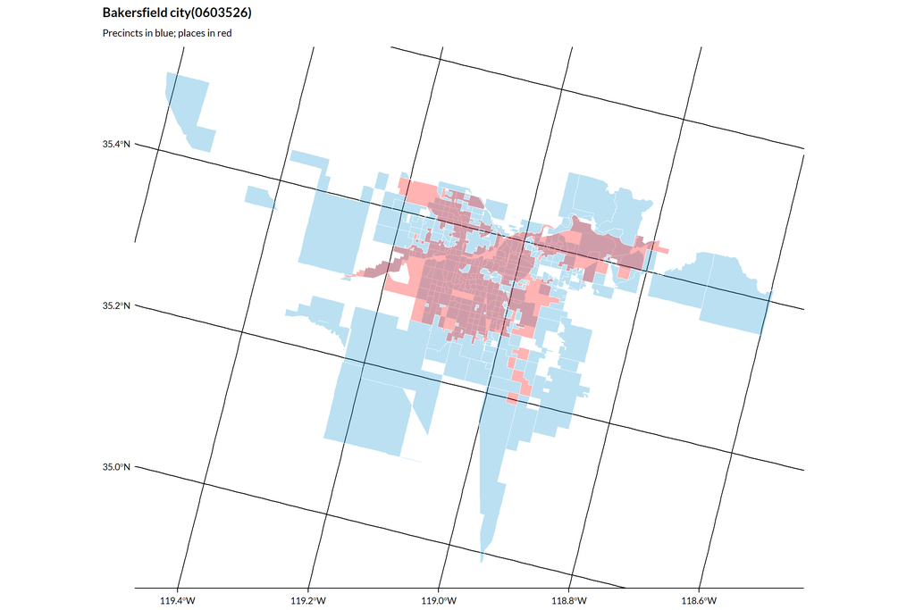

```r
map_trouble("0603526")
```